# Faster `rank(::QRPivoted)` function

Benchmarking implementations of rank functions

Julia

Linear Algebra

Author

Affiliation

[Ajinkya Kokandakar](https://ajinkya-k.github.io/)

[University of Wisconsin, Madison](https://www.wisc.edu/)

Published

November 28, 2024

# Why am I writing about this?

The current implementation of the rank method for pivoted QR decomposition in julia is slow and inefficient. The modified version proposed here improves run time by orders of magnitude.

# Load necessary packages

```julia
using LinearAlgebra
using Chairmarks
using PrettyChairmarks
using Statistics
import LinearAlgebra: rank
using TidierPlots
using DataFrames

TidierPlots_set("plot_show", false)
```

```
false
```

# Computing the rank from a pivoted QR decomposition

Let’s generate a $n \times n$ matrix say $A$ with rank $r$, by first generating a $n \times r$ matrix and then computing its outerproduct.

```julia
n = 100
r = 20

X = randn(n, r)

outprod(X::Matrix) = X * X'
A = X * X'

π
```

Now let’s compute the pivoted QR factorization of A.

```julia
Aqr = qr(A, ColumnNorm());
```

# Generate matrix of known rank

The following function generates a $n \times m$ matrix of rank $r \leq \min(n, m)$. We will use this for benchmarking the implementations. This function was based on a stackoverflow answer [here](https://stackoverflow.com/a/10149972).

```julia
# Generate an `n × m` matrix of rank `r`
function generatematrix(n::T, m::T, r::T) where {T<:Integer}
    A = randn(n, r)
    B = randn(m, r)
    return A * B'
end
```

```
generatematrix (generic function with 1 method)
```

# Computing the rank

The current implmentation in the `julia` repo is as follows:

```julia
function rank(A::QRPivoted; atol::Real=0, rtol::Real=min(size(A)...) * eps(real(float(one(eltype(A.Q))))) * iszero(atol))
    m = min(size(A)...)
    m == 0 && return 0
    tol = max(atol, rtol*abs(A.R[1,1]))
    return something(findfirst(i -> abs(A.R[i,i]) <= tol, 1:m), m+1) - 1
end
```

```
rank (generic function with 16 methods)
```

The following implementation (`ranfast`) is orders of magnitude faster. See sections below for tests and benchmarks.

```julia
function rankfast(A::QRPivoted; atol::Real=0, rtol::Real=min(size(A)...) * eps(real(float(one(eltype(A.Q))))) * iszero(atol))
    m = min(size(A)...)
    m == 0 && return 0
    rdiag = diag(getfield(A, :factors))
    tol = max(atol, rtol*abs(rdiag[1]))

    return something(findfirst(abs.(rdiag) .<= tol), m+1) - 1
end
```

```
rankfast (generic function with 1 method)
```

```julia
rank(Aqr) == rankfast(Aqr)
```

```
true
```

```julia
rankbench = @bs rank($Aqr)
```

```
Chairmarks.Benchmark: 459 samples with 1 evaluation.
 Range (min … max):   82.625 μs … 909.917 μs  ┊ GC (min … max):  0.00% … 82.97%
 Time  (median):     136.292 μs               ┊ GC (median):     0.00%
 Time  (mean ± σ):   167.129 μs ±  83.371 μs  ┊ GC (mean ± σ):  13.01% ± 25.16%

        ▁█ ▁▃▃
  ▃▃▄▆▆▇██▆███▄▅▆▃▃▃▃▂▂▂▂▁▁▁▁▁▂▄▂▂▂▄▂▄▃▃▃▃▃▃▃▃▂▃▃▃▃▂▂▃▂▁▂▂▁▁▁▁▂ ▃
  82.6 μs          Histogram: frequency by time          403 μs <

 Memory estimate: 1.68 MiB, allocs estimate: 67.
```

```julia
rankfastbench = @bs rankfast($Aqr)
```

```
Chairmarks.Benchmark: 2614 samples with 273 evaluations.
 Range (min … max):   87.758 ns …  24.794 μs  ┊ GC (min … max): 0.00% … 99.10%
 Time  (median):      97.377 ns               ┊ GC (median):    0.00%
 Time  (mean ± σ):   131.324 ns ± 554.926 ns  ┊ GC (mean ± σ):  1.68% ± 12.06%

  █▆▁▁
  ████▆▃▅▄▁▁▁▁▃▁▁▁▁▁▁▁▁▁▁▁▁▁▁▁▁▁▁▁▁▁▁▁▁▁▁▁▁▁▁▁▁▁▁▁▁▁▁▁▁▁▄▅▅▁▅▄▆ █
  87.8 ns       Histogram: log(frequency) by time        815 ns <

 Memory estimate: 1.05 KiB, allocs estimate: 6.
```

# Varying the rank

```julia
n = 100; m = 30


benchs = Vector{Chairmarks.Benchmark}()
benchf = Vector{Chairmarks.Benchmark}()


for r in 1:min(n,m)
  _qrA = qr(generatematrix(n, m, r), ColumnNorm())
  _br = @be rank($_qrA)
  _brf = @be rankfast($_qrA)

  if (rank(_qrA) != rankfast(_qrA))
    println("uh oh rank didnt match")
  else
    print(".")
  end

  push!(benchs, _br)
  push!(benchf, _brf)
end
```

```
..............................
```

```julia
medslow = [median(bnc) for bnc in benchs]
medfast = [median(bnc) for bnc in benchf]
```

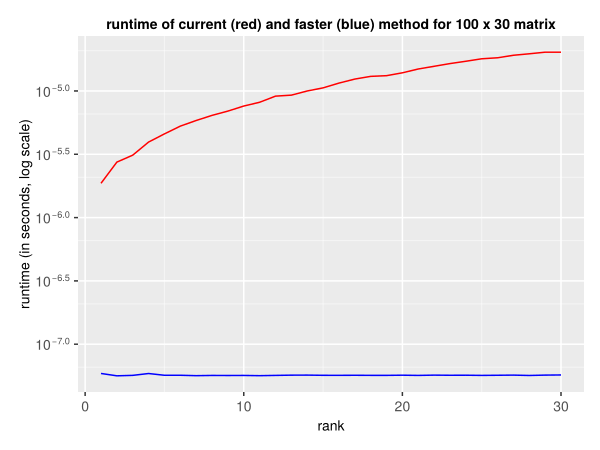

```julia
xs = collect(1:min(m,n))

df = DataFrame(
  rank = xs,
  median_time = [b.time for b in medslow],
  median_time_fast = [b.time for b in medfast],
  medianbytes = [b.bytes for b in medslow],
  medianbytes_fast = [b.bytes for b in medfast])

ggplot(df) +
  geom_line(
    @aes(x = rank, y = median_time), color = "red"
  ) +
  geom_line(
    @aes(x = rank, y = median_time_fast), color = "blue"
  ) +
  labs(
    x = "rank",
    y = "runtime (in seconds, log scale)",
    title = "runtime of current (red) and faster (blue) method for $n x $m matrix"
  ) +
  scale_y_log10()
```

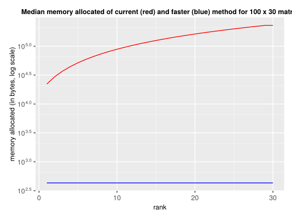

```julia
xs = collect(1:min(m,n))

ggplot(df) +
  geom_line(
    @aes(x = rank, y = medianbytes), color = "red"
  ) +
  geom_line(
    @aes(x = rank, y = medianbytes_fast), color = "blue"
  ) +
  labs(x = "rank",
  y = "memory allocated (in bytes, log scale)", title = "Median memory allocated of current (red) and faster (blue) method for $n x $m matrix") +
  scale_y_log10()
```

# Why is the current implementaiton so slow?

It’s slow because it calls `Aqr.R` for every diagonal entry, which leads to computing the upper triangular matrix each time! If `min(n, m)` is large, that can mean recreating this matrix a lot of times! The code below demonstrates this.

```julia
A = generatematrix(10000, 100, 80);
Aqr = qr(A, ColumnNorm());
```

```julia
@bs for i in 1:min(size(A)...) Aqr.R[i,i] end
```

```
Chairmarks.Benchmark: 79 samples with 1 evaluation.
 Range (min … max):  523.791 μs … 10.242 ms  ┊ GC (min … max):  0.00% … 91.31%
 Time  (median):     802.542 μs              ┊ GC (median):     0.00%
 Time  (mean ± σ):     1.069 ms ±  1.172 ms  ┊ GC (mean ± σ):  12.42% ± 24.73%

    ▇█▄▅  ▃
  ▇████████▆▃▁▃▅▁▁▁▁▁▁▁▃▁▃▁▁▁▁▁▃▁▃▁▃▁▁▁▁▁▁▁▁▃▁▁▁▁▁▁▁▁▁▁▁▁▁▁▁▁▃ ▁
  524 μs          Histogram: frequency by time         3.83 ms <

 Memory estimate: 7.64 MiB, allocs estimate: 503.
```

```julia
@bs for i in 1:min(size(A)...) Aqr.factors[i,i] end
```

```
Chairmarks.Benchmark: 3082 samples with 5 evaluations.
 Range (min … max):  5.192 μs … 997.425 μs  ┊ GC (min … max): 0.00% … 98.34%
 Time  (median):     5.550 μs               ┊ GC (median):    0.00%
 Time  (mean ± σ):   6.016 μs ±  17.884 μs  ┊ GC (mean ± σ):  0.03% ±  1.77%

  ▄██▆▆▄▂▂▅▇▆▅▅▂▃▂▁ ▁                                         ▁
  ████████████████████▇▆▇█▇▆██▇▆▇▇▇▅█▇▆▅▅▅▄▆▇▇█▇▇▇▅▅▄▃▄▄▃▃▃▄▄ █
  5.19 μs      Histogram: log(frequency) by time      8.01 μs <

 Memory estimate: 4.77 KiB, allocs estimate: 203.
```

```julia
@bs Aqr.R[1,1]
```

```
Chairmarks.Benchmark: 8019 samples with 1 evaluation.
 Range (min … max):  3.791 μs …  1.516 ms  ┊ GC (min … max): 0.00% … 98.72%
 Time  (median):     7.000 μs              ┊ GC (median):    0.00%
 Time  (mean ± σ):   9.371 μs ± 47.494 μs  ┊ GC (mean ± σ):  0.21% ±  4.49%

   ▄           ▃▆█▅▂
  ▄█▄▂▂▁▁▁▁▁▂▂▅█████▇▅▄▄▄▃▃▃▂▂▂▂▂▂▂▂▂▂▁▁▁▂▁▁▁▁▁▁▁▁▁▁▁▁▁▁▁▁▁▁ ▂
  3.79 μs        Histogram: frequency by time        15.6 μs <

 Memory estimate: 78.33 KiB, allocs estimate: 8.
```

```julia
@bs Aqr.factors[1,1]
```

```
Chairmarks.Benchmark: 3405 samples with 899 evaluations.
 Range (min … max):  27.623 ns …  4.305 μs  ┊ GC (min … max): 0.00% … 98.71%
 Time  (median):     28.133 ns              ┊ GC (median):    0.00%
 Time  (mean ± σ):   30.532 ns ± 73.325 ns  ┊ GC (mean ± σ):  0.03% ±  1.69%

  ▅█▇▂▅▄▂ ▁  ▂▆▃                                              ▁
  ███████▇█▆████▇▆██▆▄▆▇▆▆▇▇▇▅▆▆▅▅▆▆▄▇▅▅▆▄▆▅▅▄▄▅▄▃▃▆▆▃▄▄▆▄▆▄▃ █
  27.6 ns      Histogram: log(frequency) by time      39.9 ns <

 Memory estimate: 16.124582869855395 bytes, allocs estimate: 1.
```

# Alloc can get bad for large matrices!

If the matrix is large (even if the rank is small), the current method allocates too much! See example below.

```julia
Mqr = qr(generatematrix(1000, 100, 50), ColumnNorm());
```

```julia
@bs rank($Mqr)
```

```
Chairmarks.Benchmark: 169 samples with 1 evaluation.
 Range (min … max):  198.292 μs …   5.292 ms  ┊ GC (min … max): 0.00% … 92.62%
 Time  (median):     413.875 μs               ┊ GC (median):    0.00%
 Time  (mean ± σ):   568.746 μs ± 590.756 μs  ┊ GC (mean ± σ):  8.51% ± 24.13%

      ▅▇█▁
  ▄▃▃▄████▄▅▁▃▁▂▁▁▁▂▁▁▁▁▁▁▃▁▃▂▁▂▁▂▂▁▂▁▁▃▃▂▁▁▁▂▁▁▁▁▁▁▁▁▁▂▁▁▁▁▁▁▂ ▂
  198 μs           Histogram: frequency by time         2.35 ms <

 Memory estimate: 3.97 MiB, allocs estimate: 157.
```

```julia
@bs rankfast($Mqr)
```

```
Chairmarks.Benchmark: 3425 samples with 154 evaluations.
 Range (min … max):   86.305 ns … 60.465 μs  ┊ GC (min … max): 0.00% … 99.48%
 Time  (median):     110.656 ns              ┊ GC (median):    0.00%
 Time  (mean ± σ):   169.068 ns ±  1.275 μs  ┊ GC (mean ± σ):  0.23% ±  4.76%

  ▁  ▆█▂
  ██▆███▆▅▆▄▅▆▆▅▇▇▆▅▄▄▄▄▄▄▃▃▂▂▂▂▂▂▂▂▂▂▂▂▁▂▂▂▁▂▂▂▁▂▁▁▁▁▁▂▂▁▁▁▁▂ ▃
  86.3 ns         Histogram: frequency by time          278 ns <

 Memory estimate: 1.05 KiB, allocs estimate: 6.
```